# Statistical inference with the GSS data

## Setup

### Load packages

```r
library(ggplot2)
library(dplyr)
library(statsr)
library(reshape2)
```

### Load data

Make sure your data and R Markdown files are in the same directory. When loaded your data file will be called `gss`. Delete this note when before you submit your work.

```r
load("gss.Rdata")
```

## Part 1: Data

The findings from this data can be generalized to all adults in the United States, since random sampling was used to find candidates for house interviews. More specifically, the survey uses cluster sampling to identify areas/clusters for canvas, and for each cluster, a stratified sample was taken with quotas based on sex, age, and employment status. As a result, the sampling method is multi-stage and is able to generalize to US adults with little bias due to demographic imbalance (due to the quota sampling) and without using as much resources compared to a simple random sample. As with all surveys, there is some non-response bias, but it was minimized by limiting canvas and interviews to after 3 pm on weekdays or during weekend or holidays*.

Any correlation between variables found through analyzing the data should not be taken as causation, since an experiment was not designed and subjects were not randomly assigned to different groups of one variable. Hence, any difference observed between those groups might be caused by some other underlying differences between those groups, and not directly by that variable itself.

* Smith, T., Hout, M. and Marsden, P. (2018). General Social Survey, 1972-2012. [PDF] Inter-university Consortium for Political and Social Research, pp.2881-2882. Available at: https://www.icpsr.umich.edu/cgi-bin/file?comp=none&study=34802&ds=1&file_id=1136502&path= [Accessed 18 Mar. 2018].

## Part 2: Research question

**Research question:** Are level of education (by highest degree obtained) and self-perceived social class dependent?

**Why this interests me**: As a college graduate, I perceive myself as middle class due to my income level. However, I wonder if there’s a dependence between education level and perceived social class, since I’ve been told that the more educated one is, the higher income one earns, and that might affect how one perceive his or her social class. Furthermore, a person who perceives him- or herself to belong to a lower social class might tend not to pursue higher education.

Therefore, if there’s indeed no difference in proportion of perceived social class among different education levels, the survey finding can be used to dispute that claim or not.

## Part 3: Exploratory data analysis

**Research question:** Are level of education (by highest degree obtained) and perceived social class dependent?

1. Select relevant columns and remove rows with missing data (*degree*: highest degree earned, *class*: self-perceived social class). There was one person who answered ‘No Class’, which can be dropped from the data since this label provides no meaningful interpretation.

```r
gss1 <- gss %>%
select(degree, class) %>%
na.omit() %>%
filter(class != 'No Class') %>%
droplevels()
```

2. Plotting proportion of social class versus education level shows that at higher education levels, a larger portion of people perceives themselves as upper and middle class and a smaller portion perceives themselves as lower and working class. The greatest difference between (middle + upper) class and (lower + working) class is between those with junior college degrees and bachelor degrees.

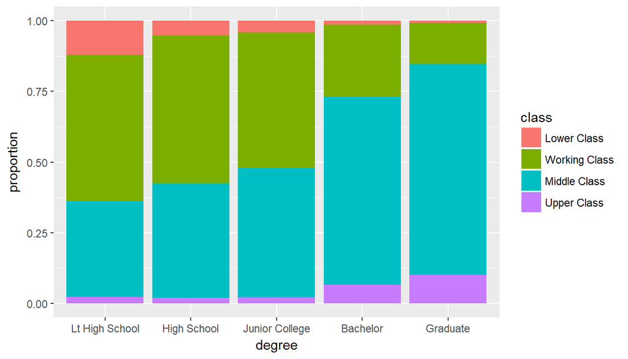

```r
ggplot(gss1) +
geom_bar(aes(x = degree, fill = class), position = 'fill') +
ylab('proportion')
```

3. Calculating the perceived social class proportion for each education level reaches the same conclusion: in general, the more advanced the highest degree earned is, the higher proportions of perceived middle and upper class people and the lower proportions of perceived lower and working class people there are for that group.

```r
# Cell count table
gss_table <- table(gss1$class, gss1$degree)
gss_table
```

```
##
##                 Lt High School High School Junior College Bachelor
##   Lower Class             1322        1450            120      109
##   Working Class           5721       14407           1396     1919
##   Middle Class            3732       11194           1332     5021
##   Upper Class              255         538             62      493
##
##                 Graduate
##   Lower Class         26
##   Working Class      534
##   Middle Class      2718
##   Upper Class        368
```

```r
# Table of class proportion (relative to total people in each education level group)
prop.table(gss_table, 2) * 100
```

```
##
##                 Lt High School High School Junior College   Bachelor
##   Lower Class       11.9854941   5.2557179      4.1237113  1.4452400
##   Working Class     51.8676337  52.2200877     47.9725086 25.4441793
##   Middle Class      33.8349955  40.5741419     45.7731959 66.5738531
##   Upper Class        2.3118767   1.9500526      2.1305842  6.5367277
##
##                   Graduate
##   Lower Class    0.7131103
##   Working Class 14.6461876
##   Middle Class  74.5474493
##   Upper Class   10.0932529
```

## Part 4: Inference

## Hypothesis

**H0:** there is no difference in social class self-perception across education levels

**H1:** there is a difference in social class self-perception across education levels

## Conditions

**Independence condition**: Since the survey sample is randomly selected and composed of less than 10% of the US adult population (across all sub-groups), and we have no reason to believe that the answers from the people surveyed are significantly related, the independence condition for chi-square test is met.

**Sample size condition**: Since the expected count for all counts under null hypothesis (see below) are all greater than 5, the sample size condition for chi-square test is met.

```r
row_sums <- margin.table(gss_table, 1)
row_p <- row_sums / sum(gss_table)
column_sums <- margin.table(gss_table, 2)
expected_table <- outer(row_p, column_sums)
expected_table
```

```
##
##                 Lt High School High School Junior College  Bachelor
##   Lower Class         633.3405   1584.1551       167.0916  433.0602
##   Working Class      5016.7178  12548.1619      1323.5402 3430.2888
##   Middle Class       5020.9024  12558.6288      1324.6442 3433.1501
##   Upper Class         359.0394    898.0542        94.7239  245.5009
##
##                  Graduate
##   Lower Class    209.3526
##   Working Class 1658.2913
##   Middle Class  1659.6745
##   Upper Class    118.6816
```

## Hypothesis testing method

**Method**: Chi-square test for independence (between 2 categorical variables)

**How**: under the null hypothesis, the two variables (class and education level) are independent. As a result, the proportions of perceived social class would be identical across education levels, and the difference between the survey proportions and the null-hypothesis proportions is represented by the chi-square test statistic.

A p-value is calculated from that chi-square value to show how likely the survey result would be obtained if the hypothesis is true, and if it’s very unlikely (under 5% significance level), then the null hypothesis can be rejected. If not, we fail to reject the null hypothesis.

## Result

1. The observed proportions look to be much different than the expected proportions under the null hypothesis (no difference in social class self-perception across education levels), suggesting a low p-value and high likelihood of rejecting the null hypothesis.

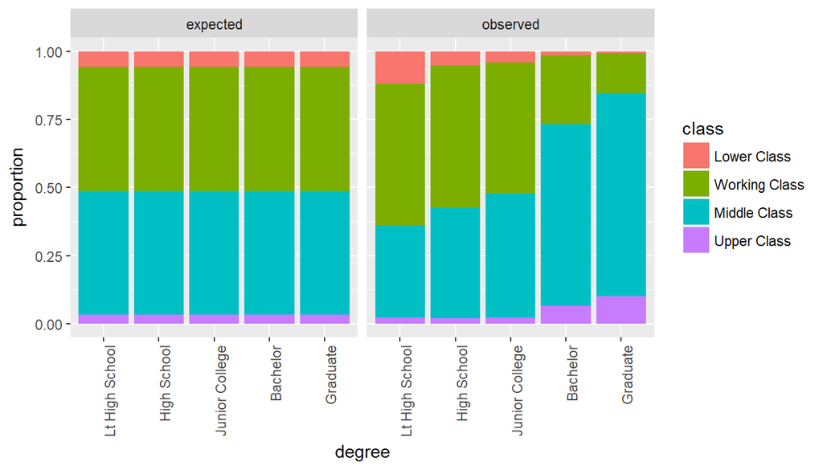

```r
observed_counts <- as.data.frame(gss_table)
observed_counts$type <- 'observed'
observed_counts <- rename(observed_counts, class = Var1, degree = Var2, count = Freq)

expected_counts <- melt(expected_table)
expected_counts$type <- 'expected'
expected_counts <- rename(expected_counts, class = Var1, degree = Var2, count = value)

rbind(observed_counts, expected_counts) %>%
ggplot() +
geom_bar(aes(x = degree, y = count, fill = class),
         stat = 'identity', position = 'fill') +
theme(axis.text.x = element_text(angle = 90, hjust = 1)) +
ylab('proportion') +
facet_wrap(~ type)
```

2. Calculating chi-square test-statistic gives a chi square value of 5830. Due to this very large chi square, its p-value (at 12 degrees of freedom) is virtually zero.

```r
chi_square <- sum((gss_table - expected_table)^2 / expected_table)
chi_square
```

```
## [1] 5830.319
```

```r
df <- (length(unique(gss1$class)) - 1) * (length(unique(gss1$degree)) - 1)
df
```

```
## [1] 12
```

```r
pchisq(chi_square, df, lower.tail = FALSE)
```

```
## [1] 0
```

## Conclusion

Since the p-value of the chi-square test statistic is less than 0.05, the null hypothesis (there is no difference in social class self-perception across education levels) is rejected at 5% significance level. In other words, the survey data provide convincing evidence that social class self-perception is indeed different across education levels.